# Time to extinction eda

Michael Koontz

2/26/2018

# Purpose

An exploratory data analysis to test whether the introduction regime or environmental stochasticity affected the time to extinction (max time = 5) for populations of *Tribolium* flour beetles.

```r
library(ggplot2)
library(lme4)
library(lsmeans)
library(multcompView)
library(tidyr)
library(dplyr)
b <- read.csv("../data/clean-establishment-data.csv")

glimpse(b)
```

```
## Observations: 917
## Variables: 42
## $ ID               <int> 1, 2, 3, 4, 5, 6, 7, 8, 9, 10, 11, 12, 13, 14...
## $ block            <int> 1, 1, 1, 1, 1, 1, 1, 1, 1, 1, 1, 1, 1, 1, 1, ...
## $ color            <fct> blue, blue, blue, blue, blue, blue, blue, blu...
## $ number           <int> 1, 1, 1, 1, 1, 1, 1, 1, 1, 1, 1, 1, 1, 1, 1, ...
## $ size             <int> 20, 20, 20, 20, 20, 20, 20, 20, 20, 20, 20, 2...
## $ environment      <fct> fluctuating, fluctuating, fluctuating, fluctu...
## $ special          <lgl> FALSE, FALSE, FALSE, FALSE, FALSE, FALSE, FAL...
## $ gap              <lgl> FALSE, FALSE, FALSE, FALSE, FALSE, FALSE, FAL...
## $ notes            <fct> , , , , , , , , , , , , , , , , , , , , , , , ,
## $ drought          <lgl> FALSE, FALSE, FALSE, TRUE, FALSE, TRUE, FALSE...
## $ N0plus1          <int> 8, 15, 10, 12, 8, 22, 16, 19, 14, 16, 16, 20,...
## $ N1plus1          <int> 19, 29, 16, 29, 17, 15, 49, 17, 27, 33, 48, 6...
## $ N2plus1          <int> 29, 14, 28, 33, 25, 28, 21, 7, 13, 50, 48, 51...
```

[output cut: 29 more lines]

# Time to extinction calculation

How should we figure out the time to extinction for these populations? Again, we can measure this as time since first introduction or time since final introduction. I’ll start with time since final introduction.

We know when populations went *finally* extinct (if they did) from the `when.extinct` column. We also know how many generations it took to complete the introduction regime by the `number` column. In a 20x1 introduction regime, `number` would be 1, and if that population went extinct in the 2nd generation after the initial introduction (the initial introduction being at generation 0), then the `when.extinct` column would be 2. The time to extinction should be 2 in this case. Does it make sense to subtract the `number` column from the `when.extinct` column, then add 1 back? That is, the `when.extinct` column *does* represent the time to extinction for the 20x1 introduction regime.

Another example using a multiply-introduced population. A 10x2 population goes extinct in the 4th generation after the initial introduction. `number` is 2, and `when.extinct` is 4. The time to extinction should be 3 generations after the final introduction. Our math still works: `when.extinct` minus `number` plus 1.

Consider the gaps in the introductions for some populations. This essentially adds another generation to the `number` column, so that’s how we can account for it. A 10x2 introduction with a gap was actually introduced across 3 generations (t0, skip t1, and then t2). If it went extinct in generation 4, then `when.extinct` is 4, `number` is 2, `gap` is 1 and the time to extinction should be `when.extinct` minus (`number` plus `gap`) plus 1 = 2.

```r
b$time.to.extinction <- b$when.extinct - (b$number + as.numeric(b$gap)) + 1
glimpse(b)
```

```
## Observations: 917
## Variables: 43
## $ ID                 <int> 1, 2, 3, 4, 5, 6, 7, 8, 9, 10, 11, 12, 13, ...
## $ block              <int> 1, 1, 1, 1, 1, 1, 1, 1, 1, 1, 1, 1, 1, 1, 1...
## $ color              <fct> blue, blue, blue, blue, blue, blue, blue, b...
## $ number             <int> 1, 1, 1, 1, 1, 1, 1, 1, 1, 1, 1, 1, 1, 1, 1...
## $ size               <int> 20, 20, 20, 20, 20, 20, 20, 20, 20, 20, 20,...
## $ environment        <fct> fluctuating, fluctuating, fluctuating, fluc...
## $ special            <lgl> FALSE, FALSE, FALSE, FALSE, FALSE, FALSE, F...
## $ gap                <lgl> FALSE, FALSE, FALSE, FALSE, FALSE, FALSE, F...
## $ notes              <fct> , , , , , , , , , , , , , , , , , , , , , ,...
## $ drought            <lgl> FALSE, FALSE, FALSE, TRUE, FALSE, TRUE, FAL...
## $ N0plus1            <int> 8, 15, 10, 12, 8, 22, 16, 19, 14, 16, 16, 2...
## $ N1plus1            <int> 19, 29, 16, 29, 17, 15, 49, 17, 27, 33, 48,...
## $ N2plus1            <int> 29, 14, 28, 33, 25, 28, 21, 7, 13, 50, 48, ...
```

[output cut: 30 more lines]

# Visualization

Let’s visualize the time to extinction

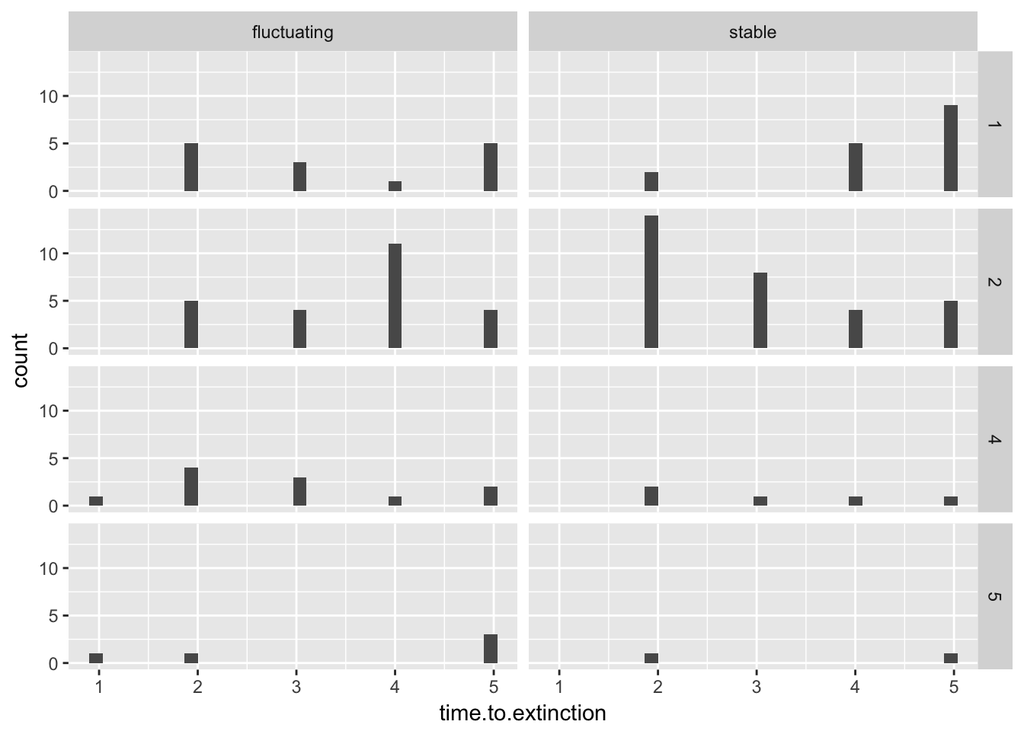

```r
b %>%
  filter(time.to.extinction <= 5) %>%
ggplot(aes(x = time.to.extinction)) +
  geom_histogram() +
  facet_grid(as.factor(number) ~ environment)
```